# Introduction to the Lemna package

Nils Kehrein

31 March, 2025

The *lemna* package provides model equations and some useful helpers to simulate the growth of *Lemna* (duckweed) aquatic plant populations. *Lemna* is a standard test macrophyte used in ecotox effect studies. The model was described and published by the SETAC Europe Interest Group Effect Modeling (Klein *et al.* 2022).

The model’s main state variable is biomass, or `BM` for short, of the simulated *Lemna* population. Growth of *Lemna* is influenced by environmental variables such as temperature, irradiation, nutrient concentrations, population density, and toxicant concentration in the surrounding medium. To consider the influence of toxicants on the plants, a one-compartment model was assumed by the authors for the mass-balance of internal toxicant mass. The total amount of internal toxicant mass is represented by state-variable `M_int`. The combination of state variables `BM` and `M_int` fully describe the state of the model system at any point in time.

To simulate a *Lemna* population, one has to define a *scenario* that consists of the following data:

- Initial system state
- A time period to simulate
- Model parameters
- Environmental variables

How these scenario elements are represented and which values are chosen depends on what one would like to achieve. Simulating the growth of *Lemna* in a controlled lab environment will likely require different inputs than *Lemna* growing in an outdoor water body, for example.

## Core functions

To make functions and sample datasets of the *lemna* package available in your R workspace, load the library first:

```r
library(lemna)
```

The package function `param_defaults()` provides a list with all suggested default parameters. Some parameter values will be missing, i.e. set to `NA`, because they are substance specific and default values would not be meaningful for these:

```r
# get list of default parameters
params <- param_defaults()
params$k_photo_max
```

```
#> [1] 0.47
```

```r
params$EC50_int # substance specific
```

```
#> [1] NA
```

```r
# get default parameters and set a custom parameter value
myparam <- param_defaults(c(EC50_int = 42))
myparam$EC50_int
```

```
#> [1] 42
```

The growth of a *Lemna* population is simulated using the `lemna()` function. The required scenario data are either supplied individually on function call or are passed as a pre-defined scenario object, such as the `metsulfuron` sample scenario:

```r
lemna(metsulfuron)
```

```
#>    time          BM        M_int       C_int   FrondNo
#> 1     0 0.001200000 0.0000000000 0.000000000  12.00000
#> 2     1 0.001725634 0.0063939067 0.221871311  17.25634
#> 3     2 0.002003771 0.0120701443 0.360701550  20.03771
#> 4     3 0.002171628 0.0164518190 0.453640790  21.71628
#> 5     4 0.002320205 0.0198229397 0.511593653  23.20205
#> 6     5 0.002467715 0.0225374005 0.546880329  24.67715
#> 7     6 0.002619619 0.0248568637 0.568187670  26.19619
#> 8     7 0.002778289 0.0269567504 0.580996626  27.78289
#> 9     8 0.002999069 0.0167083478 0.333603522  29.99069
#> 10    9 0.003711271 0.0103269725 0.166622594  37.11271
#> 11   10 0.005507806 0.0063830367 0.069395642  55.07806
#> 12   11 0.008377291 0.0039454957 0.028202105  83.77291
#> 13   12 0.012750953 0.0024390409 0.011454074 127.50953
#> 14   13 0.019407273 0.0015074611 0.004651201 194.07273
#> 15   14 0.029537211 0.0009316238 0.001888664 295.37211
```

`lemna()` returns a table which describes the change of state variables over time. In addition, some supporting derived variables such as internal toxicant concentration (`C_int`) and the number of fronds (`FrondNo`) will be returned by default.

A visual description of the simulated scenario and its results can be created by running the `plot()` function. The `plot()` function requires a simulation result as its first argument:

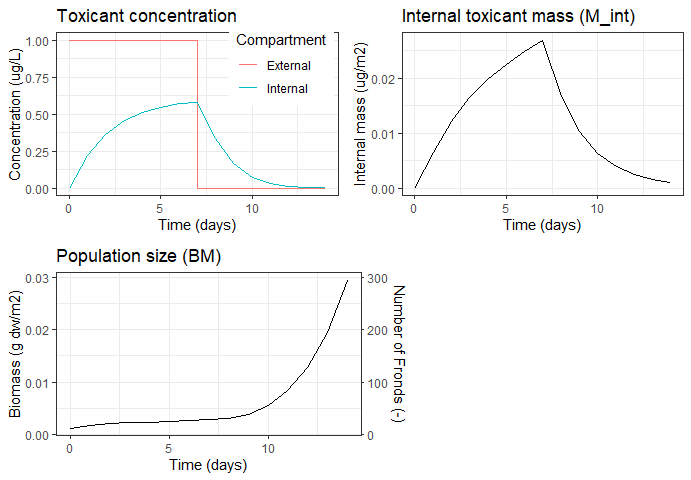

```r
plot(lemna(metsulfuron))
```

The effect of the toxicant on the *Lemna* population can be calculated using the `effect()` function. It requires scenario data the same way as `lemna()` does. For the sample `metsulfuron` scenario, the effects of the toxicant are as follows:

```r
effect(metsulfuron)
```

```
#>       BM        r
#> 93.12935 45.53310
```

In this scenario, exposure to the toxicant resulted in an 93% decrease of population size (`BM`) and a 46% decrease in average growth rate (`r`) until the end of the simulation. Effects are always calculated relative to an identical control scenario which contains no toxicant exposure.

For more information on the `metsulfuron` sample scenario, please refer to the help files:

```r
?metsulfuron
```

## Tutorial

### Simulate the *Lemna* growth model

To simulate a *Lemna* population, one has to pass the four mandatory scenario elements to the `lemna()` function:

```r
# initial state of the model system: 1.0 g dw biomass, 0.0 ug/m2 internal toxicant
myinit <- c(BM=1, M_int=0)
# simulated period and output time points: each day for 7 days
mytimes <- 0:7
# default model parameters + substance specific values
myparam <- param_defaults(c(
  EC50_int = 4.16,
  b = 0.3,
  P = 0.0054
))
# constant environmental conditions, including exposure
myenvir <- list(
  tmp = 18,    # 18 °C ambient temperature
  irr = 15000, # 15,000  kJ m-2 d-1 irradiance
  P = 0.3,     # 0.3 mg L-1 Phosphorus concentration
  N = 0.6,     # 0.6 mg L-1 Nitrogen concentration
  conc = 1     # 1 ug/L toxicant concentration
)

lemna(
  init = myinit,
  times = mytimes,
  param = myparam,
  envir = myenvir
)
```

```
#>   time       BM     M_int     C_int  FrondNo
#> 1    0 1.000000  0.000000 0.0000000 10000.00
#> 2    1 1.198841  5.028960 0.2511888 11988.41
#> 3    2 1.410120  9.480796 0.4025985 14101.20
#> 4    3 1.648541 13.628139 0.4950173 16485.41
#> 5    4 1.921189 17.702777 0.5517657 19211.89
#> 6    5 2.234682 21.897913 0.5867735 22346.82
#> 7    6 2.596018 26.379982 0.6084857 25960.18
#> 8    7 3.012897 31.299206 0.6220605 30128.97
```

The `init` argument controls at which system state the simulation starts. The `times` argument defines the length of the simulated period and for which time points results are returned. The temporal resolution of results can be increased by specifying additional output times:

```r
simresult <- lemna(
  init = myinit,
  times = seq(0, 7, 0.1), # a step length of 0.1 days = ~2 hours
  param = myparam,
  envir = myenvir
)
tail(simresult)
```

```
#>    time       BM    M_int     C_int  FrondNo
#> 66  6.5 2.797005 28.77600 0.6160568 27970.05
#> 67  6.6 2.838957 29.26990 0.6173707 28389.57
#> 68  6.7 2.881514 29.76904 0.6186253 28815.14
#> 69  6.8 2.924684 30.27355 0.6198233 29246.84
#> 70  6.9 2.968477 30.78358 0.6209675 29684.77
#> 71  7.0 3.012902 31.29926 0.6220605 30129.02
```

The resulting table now contains ten times as much rows because we decreased the step length by a factor of ten but simulated the same period, i.e. seven days. It can be observed that the state-variables differ slightly at the end of the simulation although the scenarios were otherwise identical. The differences originate from small numerical errors introduced by the solver of the model’s Ordinary Differential Equations (ODE). The step-length in time can have influence on the precision of simulation results. To decrease the solver’s step length without increasing the number of result time points, make use of the optional argument `hmax`. The smaller `hmax`, the more precise the results:

```r
# hmax=0.01 forces a maximum step length of 0.01 days = ~15 minutes
lemna(myinit, mytimes, myparam, myenvir, hmax = 0.01)
```

[output not shown]

By default, simulation results contain supporting variables such as internal toxicant concentration and total frond number. These are calculated from simulation results and model parameters for reasons of convenience. If these variables are not required, they can be disabled by setting the optional argument `nout = 0`:

```r
lemna(myinit, mytimes, myparam, myenvir, nout = 0)
```

```
#>   time       BM     M_int
#> 1    0 1.000000  0.000000
#> 2    1 1.198841  5.028960
#> 3    2 1.410120  9.480796
#> 4    3 1.648541 13.628139
#> 5    4 1.921189 17.702777
#> 6    5 2.234682 21.897913
#> 7    6 2.596018 26.379982
#> 8    7 3.012897 31.299206
```

### Using environmental time-series

The previous examples mostly assumed that environmental variables stay constant in time. To simulate a scenario with changing environmental variables, such as a temperature curve or exposure pattern, one has to define or load a data time-series. The model accepts time-series for all environmental variables, i.e. exposure concentration, temperature, irradiation, phosphorus concentration, and nitrogen concentration.

Within the scope of this package, time-series are represented by a `data.frame` containing exactly two numerical columns: the first column for time, the second for the variable’s value. The column names are irrelevant but sensible names may help documenting the data. As an example, the `metsulfuron` sample scenario contains a step-function as its exposure time-series: seven days of 1 ug/L *metsulfuron-methyl* starting at time point zero (`0.0`), followed by seven days of recovery (no exposure).

```r
metsulfuron$envir$conc
```

```
#>    time conc
#> 1  0.00    1
#> 2  7.00    1
#> 3  7.01    0
#> 4 14.00    0
```

Time points of the time-series and time points processed by the ODE solver may not always match. To derive environmental variable values which are not explicitly part of the time-series, variable values are interpolated with a linear function. If the time-series does not cover the full simulation period, the closest value from the time-series is used. In the case of the `metsulfuron` sample scenario, the step function will effectively extend to infinity, i.e. any time point before day `7.0` will have 1 ug/L of exposure and any time point after `7.01` will have no exposure.

As an example, we will modify the `metsulfuron` sample scenario to use an exposure time-series that declines linearly between start and day seven:

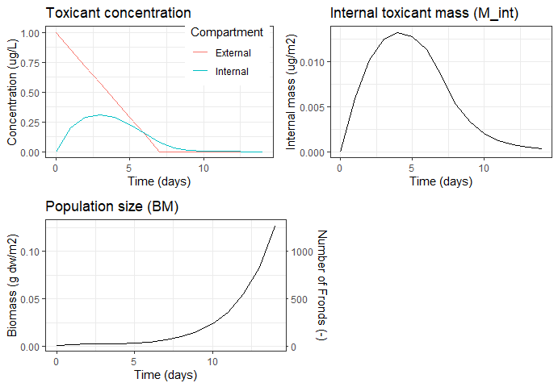

```r
# define start and end points for the exposure series, the values
# in between will be interpolated
myexpo <- data.frame(time=c(0, 7), conc=c(1, 0))
# modify the sample scenario's exposure series
myenvir <- metsulfuron$envir
myenvir$conc <- myexpo

# simulate the sample scenario with modified environmental variables
plot(lemna(metsulfuron, envir=myenvir))
```

Time-series and `data.frame` objects can be stored conveniently as `.csv` files which can be created and edited by common spreadsheet programs such as *Microsoft Excel*. Be aware that the separator character used by *R* and your spreadsheet program may differ depending on your computer’s locale settings.

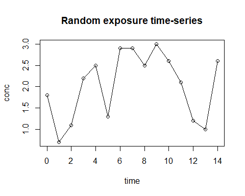

```r
set.seed(23)
# define a random time-series, values will be uniformly distributed between
# the values 0.1 and 3.0, e.g to represent an exposure time-series
myexpo <- data.frame(time = 0:14,
                     conc = round(runif(15, 0.1, 3.0), 1))
# plot the time-series
plot(myexpo, main="Random exposure time-series")
lines(myexpo)
```

```r
# write data to .csv file in working directory
write.csv(myexpo, file="random_series.csv", row.names=FALSE)
# write data using semicolons as separating character
write.csv2(myexpo, file="random_series2.csv", row.names=FALSE)

# read file from working directory
myimport <- read.csv(file="random_series.csv")
# check that written and read data are identical
myexpo$conc == myimport$conc
```

```
#>  [1] TRUE TRUE TRUE TRUE TRUE TRUE TRUE TRUE TRUE TRUE TRUE TRUE TRUE TRUE TRUE
```

Time-series can be imported manually as in the previous example or they can be imported automatically by the `lemna()` function for convenience. If an environmental variable is set to a string, it will be interpreted as a file path and `lemna()` will try to import the time-series using `read.csv()`:

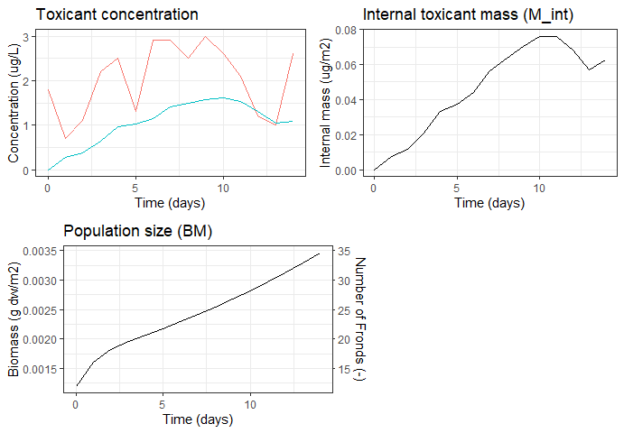

```r
# automatically load the exposure time-series from a file
myenvir <- metsulfuron$envir
myenvir$conc <- "random_series.csv"

# simulate the sample scenario with the exposure series loaded from a .csv file
plot(lemna(metsulfuron, envir=myenvir), legend=FALSE)
```

For a more complex scenario that uses hourly and daily time-series of exposure and temperature/irradiance, respectively, please have a look at e.g. the `focusd1` scenario:

```r
myenvir <- focusd1$envir
myenvir$conc
myenvir$tmp
myenvir$irr
```

[output not shown]

### Using simulation results

Simulation results are returned as a table, i.e. a `data.frame` object. The table will contain the state variables biomass (`BM`) and internal toxicant mass (`M_int`) for each requested output time point. The table may also contain additional columns for other supporting variables. The data can be processed like any other dataset in *R* to e.g. create plots, derive other values, or to perform statistical tests:

```r
myresult <- lemna(focusd1)
head(myresult)
```

```
#>   time       BM     M_int        C_int  FrondNo
#> 1    0 80.00000 0.0000000 0.0000000000 200000.0
#> 2    1 79.48177 0.6614503 0.0004983256 198704.4
#> 3    2 79.00414 2.2061048 0.0016720907 197510.3
#> 4    3 78.57538 4.1750616 0.0031817050 196438.5
#> 5    4 78.23362 6.2899397 0.0048143381 195584.0
#> 6    5 78.01035 8.3810150 0.0064332127 195025.9
```

To get an initial impression of a scenario and its results, simply pass the simulation result to the `plot()` function:

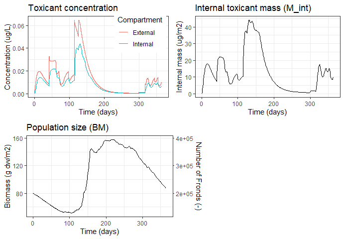

```r
plot(myresult)
```

As an example, we will analyze if and how the internal toxicant concentration (`C_int`) correlates with the internal toxicant mass (`M_int`):

```r
summary(lm(C_int ~ M_int, myresult))
```

```
#>
#> Call:
#> lm(formula = C_int ~ M_int, data = myresult)
#>
#> Residuals:
#>        Min         1Q     Median         3Q        Max
#> -0.0128492 -0.0018164 -0.0000756  0.0023663  0.0112966
#>
#> Coefficients:
#>               Estimate Std. Error t value Pr(>|t|)
#> (Intercept) -3.186e-04  3.309e-04  -0.963    0.336
#> M_int        7.748e-04  1.881e-05  41.185   <2e-16 ***
#> ---
#> Signif. codes:  0 '***' 0.001 '**' 0.01 '*' 0.05 '.' 0.1 ' ' 1
#>
#> Residual standard error: 0.004314 on 364 degrees of freedom
#> Multiple R-squared:  0.8233, Adjusted R-squared:  0.8228
#> F-statistic:  1696 on 1 and 364 DF,  p-value: < 2.2e-16
```

The linear model indicates a strong correlation of internal toxicant mass and concentration which intuitively makes sense. The correlation is not a 100% because biomass is a confounding factor in the model equations.

### Derive effect endpoints

To quantify the influence a toxicant exerts on a *Lemna* population, use the `effect()` function. It works similar to `lemna()` and accepts the same arguments in order to specify a scenario:

```r
# calculate effects on biomass in sample scenario
effect(metsulfuron)
```

```
#>       BM        r
#> 93.12935 45.53310
```

The return values describe the effect in percent (%) on the respective effect endpoint. Effects are calculated relative to a control scenario which exhibits no exposure. By default, the effect refers to the reduction in biomass (`BM`) or average growth rate (`r`) at the end of the simulation. In the example above, biomass was reduced by 93% and the growth rate was reduced by 46% in the *Lemna* population due to exposure to the toxicant.

If a scenario covers a long time period but effects are desired for an earlier time point, the scenario can be cut short by using the `duration` argument. If `duration` is set, the scenario will be clipped to the time period from `t0` to `t0 + duration`:

```r
# calculate effects on biomass after 7 days, instead of 14
effect(metsulfuron, duration=7)
```

```
#>       BM        r
#> 87.77416 71.45610
```

### Create scenario objects

A *Lemna* growth scenario consists of the following four mandatory scenario elements: model parameters, environmental variables, initial state, and output times. The elements can be passed to `lemna()` and `effect()` separately or they can be combined to a compact scenario object. All sample scenarios which were used in this tutorial are scenario objects:

```r
# list properties of the sample scenario object
metsulfuron
```

[output not shown]

Scenario objects are basically just a base *R* `list` object with some additional metadata. If correctly defined, scenario objects fully describe a scenario and can be passed to e.g. `lemna()` without additional arguments. It is, however, possible to override a scenario object’s data by passing an alternative dataset:

```r
# custom output times and time period:
# four days with a 12 hour time step
mytimes <- seq(0, 4, 0.5)

# simulate sample scenario with custom output times & period
lemna(metsulfuron, times=mytimes)
```

```
#>   time          BM       M_int     C_int  FrondNo
#> 1  0.0 0.001200000 0.000000000 0.0000000 12.00000
#> 2  0.5 0.001473874 0.003215291 0.1306301 14.73874
#> 3  1.0 0.001725627 0.006393890 0.2218716 17.25627
#> 4  1.5 0.001891853 0.009391186 0.2972463 18.91853
#> 5  2.0 0.002003761 0.012070096 0.3607018 20.03761
#> 6  2.5 0.002092620 0.014411810 0.4123934 20.92620
#> 7  3.0 0.002171612 0.016451729 0.4536416 21.71612
#> 8  3.5 0.002246676 0.018240740 0.4861670 22.46676
#> 9  4.0 0.002320186 0.019822776 0.5115938 23.20186
```

A custom scenario object can be created by passing the scenario elements to `new_lemna_scenario()`:

```r
myscenario <- new_lemna_scenario(
  init = c(BM=1, M_int=0),
  times = 0:7,
  param = param_defaults(c(EC50_int = 4.16, b = 0.3, P = 0.0054)),
  envir = list(
    tmp = 18,    # 18 °C ambient temperature
    irr = 15000, # 15,000  kJ m-2 d-1 irradiance
    P = 0.3,     # 0.3 mg L-1 Phosphorus concentration
    N = 0.6,     # 0.6 mg L-1 Nitrogen concentration
    conc = 1     # 1 ug/L toxicant concentration
  )
)
lemna(myscenario)
```

```
#>   time       BM     M_int     C_int  FrondNo
#> 1    0 1.000000  0.000000 0.0000000 10000.00
#> 2    1 1.198841  5.028960 0.2511888 11988.41
#> 3    2 1.410120  9.480796 0.4025985 14101.20
#> 4    3 1.648541 13.628139 0.4950173 16485.41
#> 5    4 1.921189 17.702777 0.5517657 19211.89
#> 6    5 2.234682 21.897913 0.5867735 22346.82
#> 7    6 2.596018 26.379982 0.6084857 25960.18
#> 8    7 3.012897 31.299206 0.6220605 30128.97
```

### Speed up simulations with compiled code

The *Lemna* growth model is simulated by default using model equations implemented in pure *R*. In case many simulations have to be conducted or the time required to get results becomes an issue, the compiled code feature can be used. The *lemna* package provides an alternative implementation of the *Klein et al.* model equations using *C* code. The *C* code executes significantly faster than the pure *R* alternative.

```r
# use model implemented in pure R
tail(lemna(metsulfuron, ode_mode="r"), n = 1)
```

```
#>    time         BM        M_int       C_int  FrondNo
#> 15   14 0.02953721 0.0009316238 0.001888664 295.3721
```

```r
# use model implemented in C
tail(lemna(metsulfuron, ode_mode="c"), n = 1)
```

```
#>    time         BM        M_int       C_int  FrondNo
#> 15   14 0.02955463 0.0009327918 0.001889917 295.5463
```

```r
# Benchmark the shorter metsulfuron scenario
microbenchmark::microbenchmark(
  lemna(metsulfuron, ode_mode="r"),
  lemna(metsulfuron, ode_mode="c")
)
```

```
#> Unit: milliseconds
#>                                expr    min      lq      mean   median       uq
#>  lemna(metsulfuron, ode_mode = "r") 8.8879 9.55145 13.465282 11.14495 15.33435
#>  lemna(metsulfuron, ode_mode = "c") 3.0942 3.42695  4.499359  3.65070  4.42865
#>      max neval
#>  52.5839   100
#>  16.6578   100
```

```r
# Benchmark the more complex and longer focusd1 scenario
microbenchmark::microbenchmark(
  lemna(focusd1, ode_mode="r"),
  lemna(focusd1, ode_mode="c"),
  times = 10
)
```

```
#> Unit: milliseconds
#>                            expr      min        lq       mean     median
#>  lemna(focusd1, ode_mode = "r") 2451.420 2474.0695 2581.62195 2536.82885
#>  lemna(focusd1, ode_mode = "c")   68.078   70.0759   71.59452   71.17725
#>         uq       max neval
#>  2566.3572 3056.1124    10
#>    73.3584   75.7428    10
```

There is however a small disadvantage to using the *C* model: if there are any issues stemming from, for example, invalid parameters, the error messages raised by the *C* code might be less descriptive than those from *R*. On the other hand, the *C* code can output on demand almost all intermediary model variables which can support debugging and model understanding:

```r
# simulate and request all additional output variables
lemna(metsulfuron, ode_mode="c", nout=18)
```

```
#>    time          BM        M_int       C_int   FrondNo f_loss   f_photo
#> 1     0 0.001200000 0.0000000000 0.000000000  12.00000      1 1.0000000
#> 2     1 0.001726787 0.0063967885 0.221823152  17.26787      1 0.6195910
#> 3     2 0.002005246 0.0120766369 0.360630075  20.05246      1 0.3125871
#> 4     3 0.002173312 0.0164624775 0.453582914  21.73312      1 0.2562543
#> 5     4 0.002322051 0.0198372261 0.511555418  23.22051      1 0.2409103
#> 6     5 0.002469717 0.0225551607 0.546867719  24.69717      1 0.2350169
#> 7     6 0.002621754 0.0248769820 0.568184397  26.21754      1 0.2322782
#> 8     7 0.002780547 0.0269731848 0.580878885  27.80547      1 0.2308758
#> 9     8 0.003000889 0.0167308301 0.333849731  30.00889      1 0.3432130
#> 10    9 0.003714746 0.0103409879 0.166692653  37.14746      1 0.8251025
#> 11   10 0.005512275 0.0063915556 0.069431929  55.12275      1 0.9941538
#> 12   11 0.008383437 0.0039504913 0.028217109  83.83437      1 0.9998609
#> 13   12 0.012759052 0.0024417188 0.011459371 127.59052      1 0.9999967
#> 14   13 0.019418779 0.0015091771 0.004653737 194.18779      1 0.9999999
```

[output cut: 33 more lines]

## References

- Klein J., Cedergreen N., Heine S., Kehrein N., Reichenberger S., Rendal C., Schmitt W., Hommen U., 2022: Refined description of the *Lemna* TKTD growth model based on *Schmitt et al.* (2013) – equation system and default parameters, implementation in R. Report of the working group *Lemna* of the SETAC Europe Interest Group Effect Modeling. Version 1.1, uploaded on 09 May 2022. https://www.setac.org/group/effect-modeling.html